# Wrangle and Analyze Data

## Table of content

- 1. Introduction
- 2. Data gathering
- 3. Data assessment
  - 3.1. Quality issues
  - 3.2. Untidy data
- 4. Data cleaning
- 5. Data storage
  - 5.1. CSV file
  - 5.2. SQLite database
- 6. Data analysis

## 2. Data gathering

In this part the different documents that are needed for this wrangling and data analysis will be downloaded.There are three pieces of data:

- The WeRateDogs Twitter archive (CSV).
- The tweet image predictions (TSV).
- Each tweet's retweet count and favorite ("like") count at minimum, and any additional data you find interesting (TXT).

First of all, the libraries used in this report will be imported.

```python
# Import libraries
import pandas as pd
import numpy as np
import random
import matplotlib.pyplot as plt
import requests
import tweepy
import json
import sqlite3
import seaborn as sns

%matplotlib inline
```

**The WeRateDogs Twitter archive (CSV)**

This document was provided by Udacity, so the only needed thing is to open and read it to visualize it.

```python
# Read the CSV file
archive = pd.read_csv('twitter-archive-enhanced.csv')

# Display the head
archive.head()
```

|  | tweet_id | in_reply_to_status_id | in_reply_to_user_id | timestamp | source | text | retweeted_status_id | retweeted_status_user_id | retweeted_status_timestamp | expanded_urls | rating_numerator | rating_denominator | name | doggo | floofer | pupper | puppo |
| --- | --- | --- | --- | --- | --- | --- | --- | --- | --- | --- | --- | --- | --- | --- | --- | --- | --- |
| 0 | 892420643555336193 | NaN | NaN | 2017-08-01 16:23:56 +0000 | <a href="http://twitter.com/download/iphone" r... | This is Phineas. He's a mystical boy. Only eve... | NaN | NaN | NaN | https://twitter.com/dog_rates/status/892420643... | 13 | 10 | Phineas | None | None | None | None |
| 1 | 892177421306343426 | NaN | NaN | 2017-08-01 00:17:27 +0000 | <a href="http://twitter.com/download/iphone" r... | This is Tilly. She's just checking pup on you.... | NaN | NaN | NaN | https://twitter.com/dog_rates/status/892177421... | 13 | 10 | Tilly | None | None | None | None |
| 2 | 891815181378084864 | NaN | NaN | 2017-07-31 00:18:03 +0000 | <a href="http://twitter.com/download/iphone" r... | This is Archie. He is a rare Norwegian Pouncin... | NaN | NaN | NaN | https://twitter.com/dog_rates/status/891815181... | 12 | 10 | Archie | None | None | None | None |
| 3 | 891689557279858688 | NaN | NaN | 2017-07-30 15:58:51 +0000 | <a href="http://twitter.com/download/iphone" r... | This is Darla. She commenced a snooze mid meal... | NaN | NaN | NaN | https://twitter.com/dog_rates/status/891689557... | 13 | 10 | Darla | None | None | None | None |
| 4 | 891327558926688256 | NaN | NaN | 2017-07-29 16:00:24 +0000 | <a href="http://twitter.com/download/iphone" r... | This is Franklin. He would like you to stop ca... | NaN | NaN | NaN | https://twitter.com/dog_rates/status/891327558... | 12 | 10 | Franklin | None | None | None | None |

**The tweet image predictions (TSV)**

This data is hosted on Udacity's servers, so it should be downloaded programatically by using the requests library.

```python
# Import the data from the server
data = requests.get('https://d17h27t6h515a5.cloudfront.net/topher/2017/August/599fd2ad_image-predictions/image-predictions.tsv')

# Save the data as a TSV
with open ('image_predictions.tsv', 'wb') as file:
    file.write(data.content)

# Read and display the head
img_pred = pd.read_table('image_predictions.tsv')
img_pred.head()
```

|  | tweet_id | jpg_url | img_num | p1 | p1_conf | p1_dog | p2 | p2_conf | p2_dog | p3 | p3_conf | p3_dog |
| --- | --- | --- | --- | --- | --- | --- | --- | --- | --- | --- | --- | --- |
| 0 | 666020888022790149 | https://pbs.twimg.com/media/CT4udn0WwAA0aMy.jpg | 1 | Welsh_springer_spaniel | 0.465074 | True | collie | 0.156665 | True | Shetland_sheepdog | 0.061428 | True |
| 1 | 666029285002620928 | https://pbs.twimg.com/media/CT42GRgUYAA5iDo.jpg | 1 | redbone | 0.506826 | True | miniature_pinscher | 0.074192 | True | Rhodesian_ridgeback | 0.072010 | True |
| 2 | 666033412701032449 | https://pbs.twimg.com/media/CT4521TWwAEvMyu.jpg | 1 | German_shepherd | 0.596461 | True | malinois | 0.138584 | True | bloodhound | 0.116197 | True |
| 3 | 666044226329800704 | https://pbs.twimg.com/media/CT5Dr8HUEAA-lEu.jpg | 1 | Rhodesian_ridgeback | 0.408143 | True | redbone | 0.360687 | True | miniature_pinscher | 0.222752 | True |
| 4 | 666049248165822465 | https://pbs.twimg.com/media/CT5IQmsXIAAKY4A.jpg | 1 | miniature_pinscher | 0.560311 | True | Rottweiler | 0.243682 | True | Doberman | 0.154629 | True |

**Each tweet's retweet count and favorite ("like") count at minimum, and any additional data you find interesting (TXT)**

In this part the Twitter API for each tweet's JSON data using Python's Tweepy library needed to be stored in a file called tweet_json.txt file. For this an account of Twitter was needed, but as for personal reasons I do not want to create an account, Udacity also provided me with this file. Then the only needed thing is to read and display it.

```python
# Read API data line by line
with open('tweet-json.txt') as f:
    api = pd.DataFrame((json.loads(line) for line in f), columns = ['id', 'favorite_count', 'retweet_count'])

# Display the head
api.head()
```

|  | id | favorite_count | retweet_count |
| --- | --- | --- | --- |
| 0 | 892420643555336193 | 39467 | 8853 |
| 1 | 892177421306343426 | 33819 | 6514 |
| 2 | 891815181378084864 | 25461 | 4328 |
| 3 | 891689557279858688 | 42908 | 8964 |
| 4 | 891327558926688256 | 41048 | 9774 |

## 3. Data assessment

The data assessment will be done programatically for each of the datasets, which are:

- archive: information about each tweet
- img_pred: predictions of the images in the tweets
- api: number of retweets and favourites per each tweet

**Assessing the *archive* dataset**

```python
# Display the head
archive.head(10)
```

|  | tweet_id | in_reply_to_status_id | in_reply_to_user_id | timestamp | source | text | retweeted_status_id | retweeted_status_user_id | retweeted_status_timestamp | expanded_urls | rating_numerator | rating_denominator | name | doggo | floofer | pupper | puppo |
| --- | --- | --- | --- | --- | --- | --- | --- | --- | --- | --- | --- | --- | --- | --- | --- | --- | --- |
| 0 | 892420643555336193 | NaN | NaN | 2017-08-01 16:23:56 +0000 | <a href="http://twitter.com/download/iphone" r... | This is Phineas. He's a mystical boy. Only eve... | NaN | NaN | NaN | https://twitter.com/dog_rates/status/892420643... | 13 | 10 | Phineas | None | None | None | None |
| 1 | 892177421306343426 | NaN | NaN | 2017-08-01 00:17:27 +0000 | <a href="http://twitter.com/download/iphone" r... | This is Tilly. She's just checking pup on you.... | NaN | NaN | NaN | https://twitter.com/dog_rates/status/892177421... | 13 | 10 | Tilly | None | None | None | None |
| 2 | 891815181378084864 | NaN | NaN | 2017-07-31 00:18:03 +0000 | <a href="http://twitter.com/download/iphone" r... | This is Archie. He is a rare Norwegian Pouncin... | NaN | NaN | NaN | https://twitter.com/dog_rates/status/891815181... | 12 | 10 | Archie | None | None | None | None |
| 3 | 891689557279858688 | NaN | NaN | 2017-07-30 15:58:51 +0000 | <a href="http://twitter.com/download/iphone" r... | This is Darla. She commenced a snooze mid meal... | NaN | NaN | NaN | https://twitter.com/dog_rates/status/891689557... | 13 | 10 | Darla | None | None | None | None |
| 4 | 891327558926688256 | NaN | NaN | 2017-07-29 16:00:24 +0000 | <a href="http://twitter.com/download/iphone" r... | This is Franklin. He would like you to stop ca... | NaN | NaN | NaN | https://twitter.com/dog_rates/status/891327558... | 12 | 10 | Franklin | None | None | None | None |
| 5 | 891087950875897856 | NaN | NaN | 2017-07-29 00:08:17 +0000 | <a href="http://twitter.com/download/iphone" r... | Here we have a majestic great white breaching ... | NaN | NaN | NaN | https://twitter.com/dog_rates/status/891087950... | 13 | 10 | None | None | None | None | None |
| 6 | 890971913173991426 | NaN | NaN | 2017-07-28 16:27:12 +0000 | <a href="http://twitter.com/download/iphone" r... | Meet Jax. He enjoys ice cream so much he gets ... | NaN | NaN | NaN | https://gofundme.com/ydvmve-surgery-for-jax,ht... | 13 | 10 | Jax | None | None | None | None |
| 7 | 890729181411237888 | NaN | NaN | 2017-07-28 00:22:40 +0000 | <a href="http://twitter.com/download/iphone" r... | When you watch your owner call another dog a g... | NaN | NaN | NaN | https://twitter.com/dog_rates/status/890729181... | 13 | 10 | None | None | None | None | None |
| 8 | 890609185150312448 | NaN | NaN | 2017-07-27 16:25:51 +0000 | <a href="http://twitter.com/download/iphone" r... | This is Zoey. She doesn't want to be one of th... | NaN | NaN | NaN | https://twitter.com/dog_rates/status/890609185... | 13 | 10 | Zoey | None | None | None | None |
| 9 | 890240255349198849 | NaN | NaN | 2017-07-26 15:59:51 +0000 | <a href="http://twitter.com/download/iphone" r... | This is Cassie. She is a college pup. Studying... | NaN | NaN | NaN | https://twitter.com/dog_rates/status/890240255... | 14 | 10 | Cassie | doggo | None | None | None |

```python
# Show information about the dataset
archive.info()
```

```
<class 'pandas.core.frame.DataFrame'>
RangeIndex: 2356 entries, 0 to 2355
Data columns (total 17 columns):
tweet_id                      2356 non-null int64
in_reply_to_status_id         78 non-null float64
in_reply_to_user_id           78 non-null float64
timestamp                     2356 non-null object
source                        2356 non-null object
text                          2356 non-null object
retweeted_status_id           181 non-null float64
retweeted_status_user_id      181 non-null float64
retweeted_status_timestamp    181 non-null object
expanded_urls                 2297 non-null object
rating_numerator              2356 non-null int64
rating_denominator            2356 non-null int64
name                          2356 non-null object
doggo                         2356 non-null object
floofer                       2356 non-null object
pupper                        2356 non-null object
puppo                         2356 non-null object
dtypes: float64(4), int64(3), object(10)
memory usage: 313.0+ KB
```

```python
# Show the statistics
archive.describe()
```

|  | tweet_id | in_reply_to_status_id | in_reply_to_user_id | retweeted_status_id | retweeted_status_user_id | rating_numerator | rating_denominator |
| --- | --- | --- | --- | --- | --- | --- | --- |
| count | 2.356000e+03 | 7.800000e+01 | 7.800000e+01 | 1.810000e+02 | 1.810000e+02 | 2356.000000 | 2356.000000 |
| mean | 7.427716e+17 | 7.455079e+17 | 2.014171e+16 | 7.720400e+17 | 1.241698e+16 | 13.126486 | 10.455433 |
| std | 6.856705e+16 | 7.582492e+16 | 1.252797e+17 | 6.236928e+16 | 9.599254e+16 | 45.876648 | 6.745237 |
| min | 6.660209e+17 | 6.658147e+17 | 1.185634e+07 | 6.661041e+17 | 7.832140e+05 | 0.000000 | 0.000000 |
| 25% | 6.783989e+17 | 6.757419e+17 | 3.086374e+08 | 7.186315e+17 | 4.196984e+09 | 10.000000 | 10.000000 |
| 50% | 7.196279e+17 | 7.038708e+17 | 4.196984e+09 | 7.804657e+17 | 4.196984e+09 | 11.000000 | 10.000000 |
| 75% | 7.993373e+17 | 8.257804e+17 | 4.196984e+09 | 8.203146e+17 | 4.196984e+09 | 12.000000 | 10.000000 |
| max | 8.924206e+17 | 8.862664e+17 | 8.405479e+17 | 8.874740e+17 | 7.874618e+17 | 1776.000000 | 170.000000 |

```python
# Values for source
archive.source.value_counts()
```

```
<a href="http://twitter.com/download/iphone" rel="nofollow">Twitter for iPhone</a>     2221
<a href="http://vine.co" rel="nofollow">Vine - Make a Scene</a>                          91
<a href="http://twitter.com" rel="nofollow">Twitter Web Client</a>                       33
<a href="https://about.twitter.com/products/tweetdeck" rel="nofollow">TweetDeck</a>      11
Name: source, dtype: int64
```

```python
# Values for rating_numerator
archive.rating_numerator.value_counts()
```

```
12      558
11      464
10      461
13      351
9       158
8       102
7        55
14       54
5        37
6        32
3        19
4        17
1         9
2         9
420       2
```

[output cut: 26 more lines]

```python
# Values for rating_denominator
archive.rating_denominator.value_counts()
```

```
10     2333
11        3
50        3
80        2
20        2
2         1
16        1
40        1
70        1
15        1
90        1
110       1
120       1
130       1
150       1
170       1
7         1
0         1
Name: rating_denominator, dtype: int64
```

```python
# Values of the names of the dogs
archive.name.value_counts().head(15)
```

```
None       745
a           55
Charlie     12
Oliver      11
Cooper      11
Lucy        11
Tucker      10
Lola        10
Penny       10
Bo           9
Winston      9
Sadie        8
the          8
Bailey       7
Daisy        7
Name: name, dtype: int64
```

```python
# Values of 'doggo', 'floffer', 'pupper' and 'puppo'
archive.doggo.value_counts(), archive.floofer.value_counts(), archive.pupper.value_counts(), archive.puppo.value_counts(),
```

```
(None     2259
 doggo      97
 Name: doggo, dtype: int64, None       2346
 floofer      10
 Name: floofer, dtype: int64, None      2099
 pupper     257
 Name: pupper, dtype: int64, None     2326
 puppo      30
 Name: puppo, dtype: int64)
```

```python
# Check duplicate tweet id
sum(archive.tweet_id.duplicated())
```

```
0
```

```python
# Check null tweet id
sum(archive.tweet_id.isnull())
```

```
0
```

```python
# Number of retweeted tweets
sum((archive.retweeted_status_id.isna()) == False)
```

```
181
```

**Assessing the *img_pred* dataset**

```python
# Display 5 aleatory samples
img_pred.sample(5)
```

|  | tweet_id | jpg_url | img_num | p1 | p1_conf | p1_dog | p2 | p2_conf | p2_dog | p3 | p3_conf | p3_dog |
| --- | --- | --- | --- | --- | --- | --- | --- | --- | --- | --- | --- | --- |
| 1665 | 812503143955202048 | https://pbs.twimg.com/media/C0aXTLqXEAADxBi.jpg | 2 | loupe | 0.546856 | False | web_site | 0.345298 | False | bubble | 0.010528 | False |
| 400 | 673688752737402881 | https://pbs.twimg.com/media/CVlsVs3WIAAja6m.jpg | 1 | soft-coated_wheaten_terrier | 0.340806 | True | Sealyham_terrier | 0.234898 | True | kuvasz | 0.203495 | True |
| 713 | 685325112850124800 | https://pbs.twimg.com/media/CYLDikFWEAAIy1y.jpg | 1 | golden_retriever | 0.586937 | True | Labrador_retriever | 0.398260 | True | kuvasz | 0.005410 | True |
| 904 | 700143752053182464 | https://pbs.twimg.com/media/CbdpBmLUYAY9SgQ.jpg | 1 | golden_retriever | 0.532460 | True | crossword_puzzle | 0.103796 | False | binder | 0.100371 | False |
| 17 | 666104133288665088 | https://pbs.twimg.com/media/CT56LSZWoAAlJj2.jpg | 1 | hen | 0.965932 | False | cock | 0.033919 | False | partridge | 0.000052 | False |

```python
# Display info about columns
img_pred.info()
```

```
<class 'pandas.core.frame.DataFrame'>
RangeIndex: 2075 entries, 0 to 2074
Data columns (total 12 columns):
tweet_id    2075 non-null int64
jpg_url     2075 non-null object
img_num     2075 non-null int64
p1          2075 non-null object
p1_conf     2075 non-null float64
p1_dog      2075 non-null bool
p2          2075 non-null object
p2_conf     2075 non-null float64
p2_dog      2075 non-null bool
p3          2075 non-null object
p3_conf     2075 non-null float64
p3_dog      2075 non-null bool
dtypes: bool(3), float64(3), int64(2), object(4)
memory usage: 152.1+ KB
```

```python
# Display statistics
img_pred.describe()
```

|  | tweet_id | img_num | p1_conf | p2_conf | p3_conf |
| --- | --- | --- | --- | --- | --- |
| count | 2.075000e+03 | 2075.000000 | 2075.000000 | 2.075000e+03 | 2.075000e+03 |
| mean | 7.384514e+17 | 1.203855 | 0.594548 | 1.345886e-01 | 6.032417e-02 |
| std | 6.785203e+16 | 0.561875 | 0.271174 | 1.006657e-01 | 5.090593e-02 |
| min | 6.660209e+17 | 1.000000 | 0.044333 | 1.011300e-08 | 1.740170e-10 |
| 25% | 6.764835e+17 | 1.000000 | 0.364412 | 5.388625e-02 | 1.622240e-02 |
| 50% | 7.119988e+17 | 1.000000 | 0.588230 | 1.181810e-01 | 4.944380e-02 |
| 75% | 7.932034e+17 | 1.000000 | 0.843855 | 1.955655e-01 | 9.180755e-02 |
| max | 8.924206e+17 | 4.000000 | 1.000000 | 4.880140e-01 | 2.734190e-01 |

```python
# Check duplicates in the dataset, for the tweet id and the url
sum(img_pred.duplicated()), sum(img_pred.tweet_id.duplicated()), sum(img_pred.jpg_url.duplicated())
```

```
(0, 0, 66)
```

```python
# Values for p1
img_pred.p1.value_counts().head(10)
```

```
golden_retriever      150
Labrador_retriever    100
Pembroke               89
Chihuahua              83
pug                    57
chow                   44
Samoyed                43
toy_poodle             39
Pomeranian             38
malamute               30
Name: p1, dtype: int64
```

```python
# Values for p2
img_pred.p2.value_counts().head(10)
```

```
Labrador_retriever          104
golden_retriever             92
Cardigan                     73
Chihuahua                    44
Pomeranian                   42
French_bulldog               41
Chesapeake_Bay_retriever     41
toy_poodle                   37
cocker_spaniel               34
miniature_poodle             33
Name: p2, dtype: int64
```

```python
# Values for p3
img_pred.p3.value_counts().head(10)
```

```
Labrador_retriever           79
Chihuahua                    58
golden_retriever             48
Eskimo_dog                   38
kelpie                       35
kuvasz                       34
chow                         32
Staffordshire_bullterrier    32
cocker_spaniel               31
beagle                       31
Name: p3, dtype: int64
```

**Assessing the *api* dataset**

```python
# Display 5 random samples
api.sample(5)
```

|  | id | favorite_count | retweet_count |
| --- | --- | --- | --- |
| 55 | 881536004380872706 | 50199 | 16570 |
| 1799 | 676957860086095872 | 2395 | 907 |
| 1146 | 726887082820554753 | 4195 | 1677 |
| 2239 | 667915453470232577 | 222 | 59 |
| 1016 | 746818907684614144 | 5807 | 1944 |

```python
# Show the information
api.info()
```

```
<class 'pandas.core.frame.DataFrame'>
RangeIndex: 2354 entries, 0 to 2353
Data columns (total 3 columns):
id                2354 non-null int64
favorite_count    2354 non-null int64
retweet_count     2354 non-null int64
dtypes: int64(3)
memory usage: 55.2 KB
```

```python
# Show the statistics
api.describe()
```

|  | id | favorite_count | retweet_count |
| --- | --- | --- | --- |
| count | 2.354000e+03 | 2354.000000 | 2354.000000 |
| mean | 7.426978e+17 | 8080.968564 | 3164.797366 |
| std | 6.852812e+16 | 11814.771334 | 5284.770364 |
| min | 6.660209e+17 | 0.000000 | 0.000000 |
| 25% | 6.783975e+17 | 1415.000000 | 624.500000 |
| 50% | 7.194596e+17 | 3603.500000 | 1473.500000 |
| 75% | 7.993058e+17 | 10122.250000 | 3652.000000 |
| max | 8.924206e+17 | 132810.000000 | 79515.000000 |

```python
# Chech for duplicates
sum(api.duplicated()), sum(api.id.duplicated()), sum(api.favorite_count.duplicated()), sum(api.retweet_count.duplicated())
```

```
(0, 0, 347, 630)
```

```python
# Check for null values
sum(api.id.isnull()), sum(api.favorite_count.isnull()), sum(api.retweet_count.isnull())
```

```
(0, 0, 0)
```

### 3.1. Quality issues

- Q1. Wrong expanded URLs in *archive*
- Q2. Incorrect datatype of *timestamp* in *archive* it should be a datatype64
- Q3. The retweets in *archive* are not needed for the analysis
- Q4. Wrong value of *rating_denominator* in *archive* it should be always 10
- Q5. Breed dog names are in lowercase in *img_pred*
- Q6. Missing values in some columns in *archive* in *in_reply_to_status_id*, *in_reply_to_user_id*, *retweeted_status_id*, *retweeted_status_user_id* and *retweeted_status_timestamp*
- Q7. Wrong datatype for tweet_id in *archive*, *img_pred* and *api* it should be a string instead of an integer
- Q8. Difficult to read the long values of the column *source* in *archive*

### 3.2. Untidy data

- U1. There are 4 columns (doggo, floffer, pupper and puppo) in **archive** to refer to the dog stage
- U2. Three tables with the same tweet_id

## 4. Data cleaning

In this step a copy of all the dataframes will be done, to be able to display the original content if needed.

```python
# Create copy
archive_clean = archive.copy()
img_pred_clean = img_pred.copy()
api_clean = api.copy()
```

### **Q1. Wrong expanded URLs in *archive***

- There are some expanded URLs that does not come from the page Dog Rates in Twitter and they should be deleted. To do this the URLs that have the correct format will be extracted from the column *expanded_urls* and saved in a new column called *expanded_urls_correct*. Then the column *expanded_urls* will be deleted.

**Code**

```python
# Display the head of the expanded URLs to see the structure
archive_clean['expanded_urls'].head(10)
```

```
0    https://twitter.com/dog_rates/status/892420643...
1    https://twitter.com/dog_rates/status/892177421...
2    https://twitter.com/dog_rates/status/891815181...
3    https://twitter.com/dog_rates/status/891689557...
4    https://twitter.com/dog_rates/status/891327558...
5    https://twitter.com/dog_rates/status/891087950...
6    https://gofundme.com/ydvmve-surgery-for-jax,ht...
7    https://twitter.com/dog_rates/status/890729181...
8    https://twitter.com/dog_rates/status/890609185...
9    https://twitter.com/dog_rates/status/890240255...
Name: expanded_urls, dtype: object
```

```python
# Check the number of nows that have incorrect expanded URLs
archive_clean.expanded_urls.shape[0], archive_clean.expanded_urls.str.startswith('https://twitter.com/dog_rates/status/').sum()
```

```
(2356, 2099)
```

```python
# Create a new column for the correct URLs to be True
archive_clean['expanded_urls_correct'] = archive_clean['expanded_urls'].\
                                        str.extract('(https://twitter.com/dog_rates/status/\d{1,18}/photo/1)', expand=True)

# Drop the colum expanded_urls
archive_clean.drop('expanded_urls', axis=1, inplace=True)
```

**Test**

```python
# Check again the number of URLs that not come frome twitter
archive_clean.expanded_urls_correct.shape[0],\
archive_clean.expanded_urls_correct.str.startswith('https://twitter.com/dog_rates/status/').sum()
```

```
(2356, 2056)
```

```python
# Display the head to check
archive_clean['expanded_urls_correct'].head(10)
```

```
0    https://twitter.com/dog_rates/status/892420643...
1    https://twitter.com/dog_rates/status/892177421...
2    https://twitter.com/dog_rates/status/891815181...
3    https://twitter.com/dog_rates/status/891689557...
4    https://twitter.com/dog_rates/status/891327558...
5    https://twitter.com/dog_rates/status/891087950...
6    https://twitter.com/dog_rates/status/890971913...
7    https://twitter.com/dog_rates/status/890729181...
8    https://twitter.com/dog_rates/status/890609185...
9    https://twitter.com/dog_rates/status/890240255...
Name: expanded_urls_correct, dtype: object
```

### **Q2. Incorrect datatype of *timestamp* in *archive***

- The datatype of *timestamp* should be a datatype64 and not an object. Changing it will allow operations with this variable.

**Code**

```python
# Check one more time the datatype of timestamp
archive_clean.info()
```

```
<class 'pandas.core.frame.DataFrame'>
RangeIndex: 2356 entries, 0 to 2355
Data columns (total 17 columns):
tweet_id                      2356 non-null int64
in_reply_to_status_id         78 non-null float64
in_reply_to_user_id           78 non-null float64
timestamp                     2356 non-null object
source                        2356 non-null object
text                          2356 non-null object
retweeted_status_id           181 non-null float64
retweeted_status_user_id      181 non-null float64
retweeted_status_timestamp    181 non-null object
rating_numerator              2356 non-null int64
rating_denominator            2356 non-null int64
name                          2356 non-null object
doggo                         2356 non-null object
floofer                       2356 non-null object
pupper                        2356 non-null object
puppo                         2356 non-null object
expanded_urls_correct         2056 non-null object
dtypes: float64(4), int64(3), object(10)
memory usage: 313.0+ KB
```

```python
# Change the datatype to timestamp
archive_clean['timestamp'] = pd.to_datetime(archive_clean['timestamp'])
```

**Test**

```python
# Check the new datatype
archive_clean.info()
```

```
<class 'pandas.core.frame.DataFrame'>
RangeIndex: 2356 entries, 0 to 2355
Data columns (total 17 columns):
tweet_id                      2356 non-null int64
in_reply_to_status_id         78 non-null float64
in_reply_to_user_id           78 non-null float64
timestamp                     2356 non-null datetime64[ns]
source                        2356 non-null object
text                          2356 non-null object
retweeted_status_id           181 non-null float64
retweeted_status_user_id      181 non-null float64
retweeted_status_timestamp    181 non-null object
rating_numerator              2356 non-null int64
rating_denominator            2356 non-null int64
name                          2356 non-null object
doggo                         2356 non-null object
floofer                       2356 non-null object
pupper                        2356 non-null object
puppo                         2356 non-null object
expanded_urls_correct         2056 non-null object
dtypes: datetime64[ns](1), float64(4), int64(3), object(9)
memory usage: 313.0+ KB
```

### **Q3. The retweets in *archive* are not needed for the analysis**

- For the analysis only the tweets are needed and the retweets can be deleted.

**Code**

```python
# Check the number of retweets and the total amount of tweets
sum(archive_clean.retweeted_status_id.notnull()), sum(archive_clean.tweet_id.notnull())
```

```
(181, 2356)
```

```python
# Delete the rows that have retweets
archive_clean = archive_clean[archive_clean.retweeted_status_id.isnull()]
```

**Test**

```python
# Check again the number of retweets and the total amount of tweets
sum(archive_clean.retweeted_status_id.notnull()), sum(archive_clean.tweet_id.notnull())
```

```
(0, 2175)
```

### **Q4. Wrong value of *rating_denominator* in *archive***

- This variable should always have a value of 10, but that is not the case for all the rows in the dataset, and it needs to be fixed.

**Code**

```python
# Check the amount of times the rating_denominator is not 10
archive_clean.rating_denominator.value_counts()
```

```
10     2153
50        3
80        2
11        2
20        2
2         1
16        1
40        1
70        1
15        1
90        1
110       1
120       1
130       1
150       1
170       1
7         1
0         1
Name: rating_denominator, dtype: int64
```

```python
# Change the values of the column for 10
archive_clean['rating_denominator'] = 10
```

**Test**

```python
# Check the new values
archive_clean.rating_denominator.value_counts()
```

```
10    2175
Name: rating_denominator, dtype: int64
```

### **Q5. Breed dog names are in lowercase in *img_pred***

- The names of some dog breeds are in lowercase and others are separated by undercores. To be consistent the first letters will be capital letters and the underscores will be substituted for a space (this [link](https://stackoverflow.com/questions/54611750/dataframe-replace-underscore-with-blank-not-working) was useful).

**Code**

```python
# Change the underscores for spaces
img_pred_clean[['p1', 'p2', 'p3']] = img_pred_clean[['p1', 'p2', 'p3']].replace(r"_", " ", regex=True)
```

```python
# Change the datatype to a string
img_pred_clean['p1'] = img_pred_clean['p1'].astype(str)
img_pred_clean['p2'] = img_pred_clean['p2'].astype(str)
img_pred_clean['p3'] = img_pred_clean['p3'].astype(str)
# Change the first letter to capital letter
img_pred_clean['p1'] = img_pred_clean['p1'].str.title()
img_pred_clean['p2'] = img_pred_clean['p2'].str.title()
img_pred_clean['p3'] = img_pred_clean['p3'].str.title()
```

**test**

```python
# Check the changes
img_pred_clean.head()
```

|  | tweet_id | jpg_url | img_num | p1 | p1_conf | p1_dog | p2 | p2_conf | p2_dog | p3 | p3_conf | p3_dog |
| --- | --- | --- | --- | --- | --- | --- | --- | --- | --- | --- | --- | --- |
| 0 | 666020888022790149 | https://pbs.twimg.com/media/CT4udn0WwAA0aMy.jpg | 1 | Welsh Springer Spaniel | 0.465074 | True | Collie | 0.156665 | True | Shetland Sheepdog | 0.061428 | True |
| 1 | 666029285002620928 | https://pbs.twimg.com/media/CT42GRgUYAA5iDo.jpg | 1 | Redbone | 0.506826 | True | Miniature Pinscher | 0.074192 | True | Rhodesian Ridgeback | 0.072010 | True |
| 2 | 666033412701032449 | https://pbs.twimg.com/media/CT4521TWwAEvMyu.jpg | 1 | German Shepherd | 0.596461 | True | Malinois | 0.138584 | True | Bloodhound | 0.116197 | True |
| 3 | 666044226329800704 | https://pbs.twimg.com/media/CT5Dr8HUEAA-lEu.jpg | 1 | Rhodesian Ridgeback | 0.408143 | True | Redbone | 0.360687 | True | Miniature Pinscher | 0.222752 | True |
| 4 | 666049248165822465 | https://pbs.twimg.com/media/CT5IQmsXIAAKY4A.jpg | 1 | Miniature Pinscher | 0.560311 | True | Rottweiler | 0.243682 | True | Doberman | 0.154629 | True |

### **Q6. Missing values in some columns in *archive***

- There are missing values in the columns: *in_reply_to_status_id*, *in_reply_to_user_id*, *retweeted_status_id*, *retweeted_status_user_id* and *retweeted_status_timestamp*. They need to be removed, and as they are not important for the analysis the columns will be dropped.

**Code**

```python
# Nº of columns before the remove
archive_clean.shape[1]
```

```
17
```

```python
# Delete the 5 columns
archive_clean.drop(['in_reply_to_status_id', 'in_reply_to_user_id', 'retweeted_status_id', 'retweeted_status_user_id',\
                    'retweeted_status_timestamp'], axis=1, inplace=True)
```

**Test**

```python
# Nº of columns after the removing
archive_clean.shape[1]
```

```
12
```

### **Q7. Wrong datatype for tweet_id in *archive*, *img_pred* and *api***

- Change the datatype of *tweet_id* from an integer to a string, becaue it is not a number that operations, such as sum or substractions can be done. Moreover, change the name for the *api*, because it missing *tweet_* in front to be consistent with the name that the same column has in the other two datasets.

**Code**

```python
# Change the name of the column in api
api_clean.rename(columns={"id":"tweet_id"}, inplace=True)

# Change the datatype of tweet_id into a string for the three datasets
archive_clean['tweet_id'] = archive_clean['tweet_id'].astype(str)
img_pred_clean['tweet_id'] = img_pred_clean['tweet_id'].astype(str)
api_clean['tweet_id'] = api_clean['tweet_id'].astype(str)
```

**Test**

```python
# Check datatype in archive
archive_clean.info()
```

```
<class 'pandas.core.frame.DataFrame'>
Int64Index: 2175 entries, 0 to 2355
Data columns (total 12 columns):
tweet_id                 2175 non-null object
timestamp                2175 non-null datetime64[ns]
source                   2175 non-null object
text                     2175 non-null object
rating_numerator         2175 non-null int64
rating_denominator       2175 non-null int64
name                     2175 non-null object
doggo                    2175 non-null object
floofer                  2175 non-null object
pupper                   2175 non-null object
puppo                    2175 non-null object
expanded_urls_correct    1920 non-null object
dtypes: datetime64[ns](1), int64(2), object(9)
memory usage: 220.9+ KB
```

```python
# Check datatype in img_pred
img_pred_clean.info()
```

```
<class 'pandas.core.frame.DataFrame'>
RangeIndex: 2075 entries, 0 to 2074
Data columns (total 12 columns):
tweet_id    2075 non-null object
jpg_url     2075 non-null object
img_num     2075 non-null int64
p1          2075 non-null object
p1_conf     2075 non-null float64
p1_dog      2075 non-null bool
p2          2075 non-null object
p2_conf     2075 non-null float64
p2_dog      2075 non-null bool
p3          2075 non-null object
p3_conf     2075 non-null float64
p3_dog      2075 non-null bool
dtypes: bool(3), float64(3), int64(1), object(5)
memory usage: 152.1+ KB
```

```python
# Check datatype in api
api_clean.info()
```

```
<class 'pandas.core.frame.DataFrame'>
RangeIndex: 2354 entries, 0 to 2353
Data columns (total 3 columns):
tweet_id          2354 non-null object
favorite_count    2354 non-null int64
retweet_count     2354 non-null int64
dtypes: int64(2), object(1)
memory usage: 55.2+ KB
```

### **Q8. Difficult to read the long values of the column *source* in *archive***

- It is difficult to read the values of *source* because they are very long and there are only 4 different sources. Another way of naming these sources will make the understanding and analysis of the column easier.

**Code**

```python
# Check the values of the column source
archive_clean.source.value_counts()
```

```
<a href="http://twitter.com/download/iphone" rel="nofollow">Twitter for iPhone</a>     2042
<a href="http://vine.co" rel="nofollow">Vine - Make a Scene</a>                          91
<a href="http://twitter.com" rel="nofollow">Twitter Web Client</a>                       31
<a href="https://about.twitter.com/products/tweetdeck" rel="nofollow">TweetDeck</a>      11
Name: source, dtype: int64
```

```python
# Change the names of each value
archive_clean.source.replace({'<a href="http://twitter.com/download/iphone" rel="nofollow">Twitter for iPhone</a>':"Twitter for iPhone",\
                            '<a href="http://vine.co" rel="nofollow">Vine - Make a Scene</a>':"Vine",\
                            '<a href="http://twitter.com" rel="nofollow">Twitter Web Client</a>':"Twitter Web Client",\
                            '<a href="https://about.twitter.com/products/tweetdeck" rel="nofollow">TweetDeck</a>':"TweetDeck"}, inplace=True)
```

**Test**

```python
archive_clean.source.value_counts()
```

```
Twitter for iPhone    2042
Vine                    91
Twitter Web Client      31
TweetDeck               11
Name: source, dtype: int64
```

### **U1. There are 4 columns (doggo, floofer, pupper and puppo) in** archive **to refer to the dog stage**

- There are 4 columns in *archive* that are used to refer to the dog stafe. To facilitate the analysis the columns should be merged into one.

**Code**

```python
# Check the number of values for doggo
archive.doggo.value_counts()
```

```
None     2259
doggo      97
Name: doggo, dtype: int64
```

```python
# Check the number of values for floofer
archive.floofer.value_counts()
```

```
None       2346
floofer      10
Name: floofer, dtype: int64
```

```python
# Check the number of values for pupper
archive.pupper.value_counts()
```

```
None      2099
pupper     257
Name: pupper, dtype: int64
```

```python
# Check the number of values for puppo
archive.puppo.value_counts()
```

```
None     2326
puppo      30
Name: puppo, dtype: int64
```

```python
# Replace the None values
archive_clean.doggo.replace('None', '', inplace = True)
archive_clean.floofer.replace('None', '', inplace = True)
archive_clean.pupper.replace('None', '', inplace = True)
archive_clean.puppo.replace('None', '', inplace = True)
```

```python
# Join the 4 columns into one
archive_clean['dog_stage'] = archive_clean.doggo + archive_clean.floofer + archive_clean.pupper + archive_clean.puppo
```

```python
# Check the values of the columns to see if there were some with different dog stages
archive_clean.dog_stage.value_counts()
```

```
                1831
pupper           224
doggo             75
puppo             24
doggopupper       10
floofer            9
doggofloofer       1
doggopuppo         1
Name: dog_stage, dtype: int64
```

```python
# Remove column values were the dog stage is not correct
archive_clean.dog_stage.replace({'doggopupper':'', 'doggofloofer':'', 'doggopuppo':''}, inplace=True)
```

```python
# Change the row values that are empty for None
archive_clean.dog_stage.replace({'':'None'}, inplace=True)
```

```python
# Delete the 4 columns
archive_clean.drop(['doggo', 'floofer', 'pupper', 'puppo'], axis=1, inplace=True)
```

**Test**

```python
# Check the results
archive_clean.info()
```

```
<class 'pandas.core.frame.DataFrame'>
Int64Index: 2175 entries, 0 to 2355
Data columns (total 9 columns):
tweet_id                 2175 non-null object
timestamp                2175 non-null datetime64[ns]
source                   2175 non-null object
text                     2175 non-null object
rating_numerator         2175 non-null int64
rating_denominator       2175 non-null int64
name                     2175 non-null object
expanded_urls_correct    1920 non-null object
dog_stage                2175 non-null object
dtypes: datetime64[ns](1), int64(2), object(6)
memory usage: 169.9+ KB
```

```python
# Check the Values of the new column
archive_clean.dog_stage.value_counts()
```

```
None       1843
pupper      224
doggo        75
puppo        24
floofer       9
Name: dog_stage, dtype: int64
```

### **U2. Three tables with the same tweet_id**

- The three dataset of this data analysis have in common the same tweet_id, and for this reason it will be easier to work with all the columns in the same dataset.

**Code**

```python
# Check the numer of rows of each dataset
archive_clean.shape[0], img_pred_clean.shape[0], api_clean.shape[0]
```

```
(2175, 2075, 2354)
```

```python
# Use inner join to merge the rows that have the same tweet_id
df_clean = pd.merge(archive_clean, img_pred_clean, on=['tweet_id'], how='inner')
df_clean = pd.merge(df_clean, api_clean, on=['tweet_id'], how='inner')
```

**Test**

```python
# Display the head
df_clean.head()
```

|  | tweet_id | timestamp | source | text | rating_numerator | rating_denominator | name | expanded_urls_correct | dog_stage | jpg_url | ... | p1_conf | p1_dog | p2 | p2_conf | p2_dog | p3 | p3_conf | p3_dog | favorite_count | retweet_count |
| --- | --- | --- | --- | --- | --- | --- | --- | --- | --- | --- | --- | --- | --- | --- | --- | --- | --- | --- | --- | --- | --- |
| 0 | 892420643555336193 | 2017-08-01 16:23:56 | Twitter for iPhone | This is Phineas. He's a mystical boy. Only eve... | 13 | 10 | Phineas | https://twitter.com/dog_rates/status/892420643... | None | https://pbs.twimg.com/media/DGKD1-bXoAAIAUK.jpg | ... | 0.097049 | False | Bagel | 0.085851 | False | Banana | 0.076110 | False | 39467 | 8853 |
| 1 | 892177421306343426 | 2017-08-01 00:17:27 | Twitter for iPhone | This is Tilly. She's just checking pup on you.... | 13 | 10 | Tilly | https://twitter.com/dog_rates/status/892177421... | None | https://pbs.twimg.com/media/DGGmoV4XsAAUL6n.jpg | ... | 0.323581 | True | Pekinese | 0.090647 | True | Papillon | 0.068957 | True | 33819 | 6514 |
| 2 | 891815181378084864 | 2017-07-31 00:18:03 | Twitter for iPhone | This is Archie. He is a rare Norwegian Pouncin... | 12 | 10 | Archie | https://twitter.com/dog_rates/status/891815181... | None | https://pbs.twimg.com/media/DGBdLU1WsAANxJ9.jpg | ... | 0.716012 | True | Malamute | 0.078253 | True | Kelpie | 0.031379 | True | 25461 | 4328 |
| 3 | 891689557279858688 | 2017-07-30 15:58:51 | Twitter for iPhone | This is Darla. She commenced a snooze mid meal... | 13 | 10 | Darla | https://twitter.com/dog_rates/status/891689557... | None | https://pbs.twimg.com/media/DF_q7IAWsAEuuN8.jpg | ... | 0.170278 | False | Labrador Retriever | 0.168086 | True | Spatula | 0.040836 | False | 42908 | 8964 |
| 4 | 891327558926688256 | 2017-07-29 16:00:24 | Twitter for iPhone | This is Franklin. He would like you to stop ca... | 12 | 10 | Franklin | https://twitter.com/dog_rates/status/891327558... | None | https://pbs.twimg.com/media/DF6hr6BUMAAzZgT.jpg | ... | 0.555712 | True | English Springer | 0.225770 | True | German Short-Haired Pointer | 0.175219 | True | 41048 | 9774 |

5 rows × 22 columns

```python
# Check the datatypes and number of values
df_clean.info()
```

```
<class 'pandas.core.frame.DataFrame'>
Int64Index: 1994 entries, 0 to 1993
Data columns (total 22 columns):
tweet_id                 1994 non-null object
timestamp                1994 non-null datetime64[ns]
source                   1994 non-null object
text                     1994 non-null object
rating_numerator         1994 non-null int64
rating_denominator       1994 non-null int64
name                     1994 non-null object
expanded_urls_correct    1920 non-null object
dog_stage                1994 non-null object
jpg_url                  1994 non-null object
img_num                  1994 non-null int64
p1                       1994 non-null object
p1_conf                  1994 non-null float64
p1_dog                   1994 non-null bool
p2                       1994 non-null object
p2_conf                  1994 non-null float64
p2_dog                   1994 non-null bool
p3                       1994 non-null object
p3_conf                  1994 non-null float64
p3_dog                   1994 non-null bool
favorite_count           1994 non-null int64
retweet_count            1994 non-null int64
dtypes: bool(3), datetime64[ns](1), float64(3), int64(5), object(10)
memory usage: 317.4+ KB
```

## 5. Data storage

### 5.1. CSV file

```python
# Safe the dataframe into a CSv file
df_clean.to_csv('twitter_we_rate_dogs_data.csv', index=False)
```

### 5.2. SQLite database

To safe the dataframe into a SQLite database firt a connection with the database needs to be created and then store the data of the dataframe as a table (this [link](https://stackoverflow.com/questions/50803109/how-to-store-pandas-dataframe-in-sqlite-db) was checked).

```python
# Create the connexion
conn = sqlite3.connect('twitter_we_rate_dogs_data.sqlite')

# Save the dataframe into the SQLite database
df_clean.to_sql('twitter_data', conn, if_exists='replace', index=False)
```

## 6. Data analysis

First the columns and the statistics of the dataframe will be displayed.

```python
# Display the datatypes and number of values
df_clean.info()
```

```
<class 'pandas.core.frame.DataFrame'>
Int64Index: 1994 entries, 0 to 1993
Data columns (total 22 columns):
tweet_id                 1994 non-null object
timestamp                1994 non-null datetime64[ns]
source                   1994 non-null object
text                     1994 non-null object
rating_numerator         1994 non-null int64
rating_denominator       1994 non-null int64
name                     1994 non-null object
expanded_urls_correct    1920 non-null object
dog_stage                1994 non-null object
jpg_url                  1994 non-null object
img_num                  1994 non-null int64
p1                       1994 non-null object
p1_conf                  1994 non-null float64
p1_dog                   1994 non-null bool
p2                       1994 non-null object
p2_conf                  1994 non-null float64
p2_dog                   1994 non-null bool
p3                       1994 non-null object
p3_conf                  1994 non-null float64
p3_dog                   1994 non-null bool
favorite_count           1994 non-null int64
retweet_count            1994 non-null int64
dtypes: bool(3), datetime64[ns](1), float64(3), int64(5), object(10)
memory usage: 397.4+ KB
```

```python
# Display the statistics
df_clean.describe()
```

|  | rating_numerator | rating_denominator | img_num | p1_conf | p2_conf | p3_conf | favorite_count | retweet_count |
| --- | --- | --- | --- | --- | --- | --- | --- | --- |
| count | 1994.000000 | 1994.0 | 1994.000000 | 1994.000000 | 1.994000e+03 | 1.994000e+03 | 1994.000000 | 1994.000000 |
| mean | 12.280843 | 10.0 | 1.203109 | 0.593941 | 1.344195e-01 | 6.024848e-02 | 8895.725677 | 2766.753260 |
| std | 41.497718 | 0.0 | 0.560777 | 0.271954 | 1.006807e-01 | 5.089067e-02 | 12213.193181 | 4674.698447 |
| min | 0.000000 | 10.0 | 1.000000 | 0.044333 | 1.011300e-08 | 1.740170e-10 | 81.000000 | 16.000000 |
| 25% | 10.000000 | 10.0 | 1.000000 | 0.362857 | 5.393988e-02 | 1.619283e-02 | 1982.000000 | 624.750000 |
| 50% | 11.000000 | 10.0 | 1.000000 | 0.587635 | 1.174550e-01 | 4.950530e-02 | 4136.000000 | 1359.500000 |
| 75% | 12.000000 | 10.0 | 1.000000 | 0.846285 | 1.951377e-01 | 9.159438e-02 | 11308.000000 | 3220.000000 |
| max | 1776.000000 | 10.0 | 4.000000 | 1.000000 | 4.880140e-01 | 2.734190e-01 | 132810.000000 | 79515.000000 |

Then a scatter matrix will be plotted to check visually the relations between the different variables.

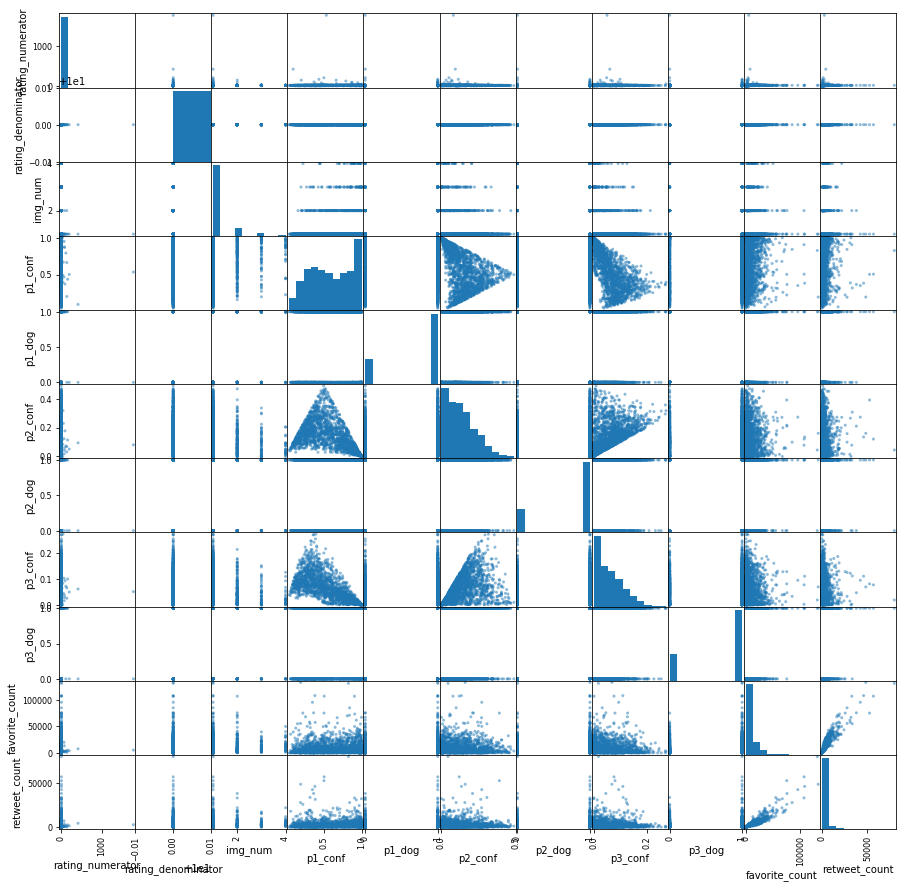

```python
# Create the scatter matrix plot
pd.plotting.scatter_matrix(df_clean, figsize=(15,15));
```

Analyse what is the relation between the dog stages and the rating numerator, favourite tweets and retweets.

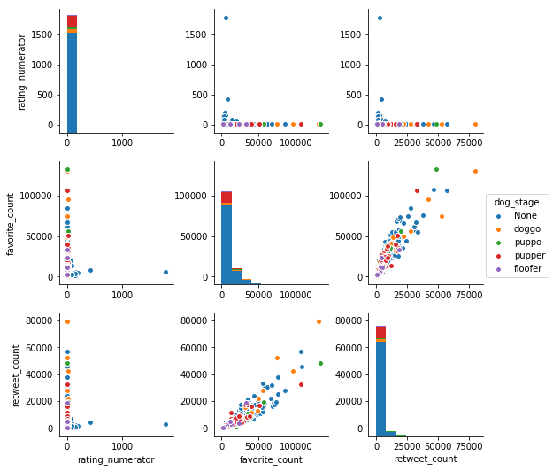

```python
# Create the pair plot
sns.pairplot(df_clean[['dog_stage', 'rating_numerator', 'favorite_count', 'retweet_count']], hue="dog_stage");
```

Now the correlation between the favorite and retweet tweets will be analysed.

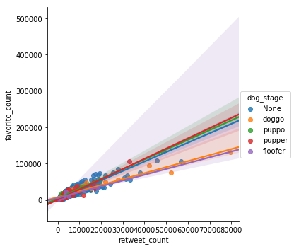

```python
# Create a plot with the linear regressions
sns.lmplot(x="retweet_count", y="favorite_count", hue="dog_stage", data=df_clean);
```

Display a pie plot to represent the percentage of each dog_stage.

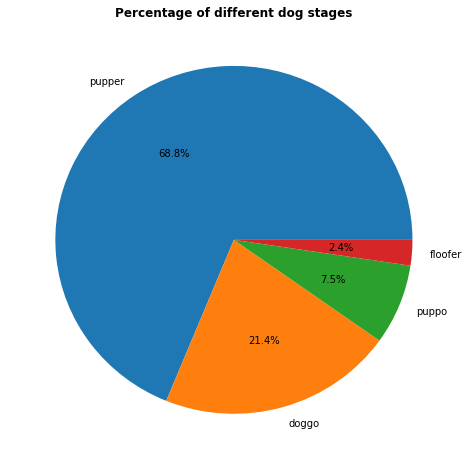

```python
# Create the pie chart
df_clean.query('dog_stage != "None"').dog_stage.value_counts().plot.pie(autopct='%1.1f%%', figsize=(8,8));
plt.title('Percentage of different dog stages', weight='bold')
plt.ylabel('')
plt.show();
```

Represent the most predicted dog breeds that had the highest favorite counts.

```python
# Group the dataset by p1 and favorite counts
fav_breeds = df_clean.groupby(['favorite_count', 'p1'], as_index=False).mean()[['favorite_count', 'p1']]

# Order them descending
fav_breeds = fav_breeds.sort_values('favorite_count', ascending=False)

# Store and show only the 15 more favorites
fav_breeds = fav_breeds[0:10]
fav_breeds
```

|  | favorite_count | p1 |
| --- | --- | --- |
| 1992 | 132810 | Lakeland Terrier |
| 1991 | 131075 | Labrador Retriever |
| 1990 | 107956 | English Springer |
| 1989 | 107015 | Chihuahua |
| 1988 | 106827 | French Bulldog |
| 1987 | 95450 | Standard Poodle |
| 1986 | 85011 | Golden Retriever |
| 1985 | 75639 | Arabian Camel |
| 1984 | 75193 | Angora |
| 1983 | 75163 | Eskimo Dog |

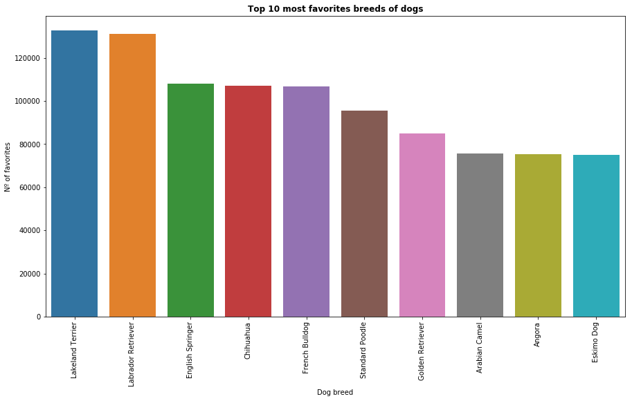

```python
# Plot in a barplot the top 10 most favorites breeds of dogs
fig_size = (15, 8)
fig, ax = plt.subplots(figsize=fig_size)
sns.barplot(data = fav_breeds, x = 'p1', y = 'favorite_count', ax=ax);

plt.title('Top 10 most favorites breeds of dogs', weight='bold')
plt.xlabel('Dog breed')
plt.ylabel('Nº of favorites')
plt.xticks(rotation=90)
plt.show();
```

Represent the most predicted dog breeds that had the highest retweets.

```python
# Group the dataset by p1 and favorite counts
retweet_breeds = df_clean.groupby(['retweet_count', 'p1'], as_index=False).mean()[['retweet_count', 'p1']]

# Order them descending
retweet_breeds = retweet_breeds.sort_values('retweet_count', ascending=False)

# Store and show only the 15 more favorites
retweet_breeds = retweet_breeds[0:10]
retweet_breeds
```

|  | retweet_count | p1 |
| --- | --- | --- |
| 1989 | 79515 | Labrador Retriever |
| 1988 | 56625 | Chihuahua |
| 1987 | 52360 | Eskimo Dog |
| 1986 | 48265 | Lakeland Terrier |
| 1985 | 45849 | English Springer |
| 1984 | 42228 | Standard Poodle |
| 1983 | 37911 | Arabian Camel |
| 1982 | 33421 | Gondola |
| 1981 | 32883 | French Bulldog |
| 1980 | 31989 | Bubble |

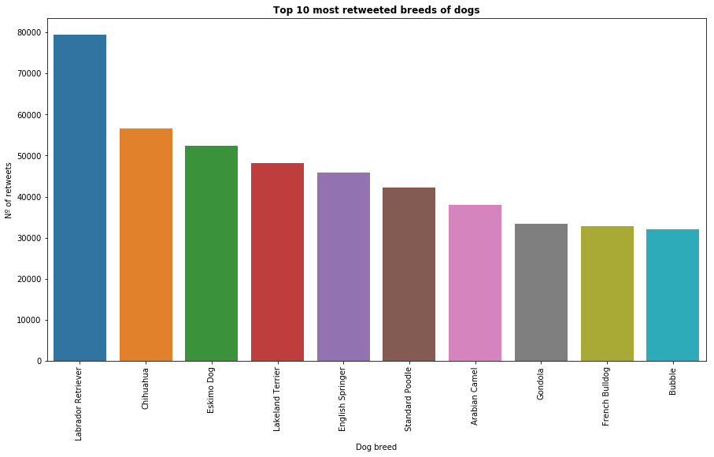

```python
# Plot in a barplot the top 10 most favorites breeds of dogs
fig_size = (15, 8)
fig, ax = plt.subplots(figsize=fig_size)
sns.barplot(data = retweet_breeds, x = 'p1', y = 'retweet_count', ax=ax);

plt.title('Top 10 most retweeted breeds of dogs', weight='bold')
plt.xlabel('Dog breed')
plt.ylabel('Nº of retweets')
plt.xticks(rotation=90)
plt.show();
```

Check the sources.

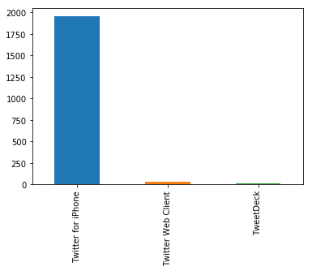

```python
df_clean['source'].value_counts().plot(kind='bar');
```